# Power

## Power

Exponent $(m)^n$

$m^n = m\times\text{m}\times\text{m}\times\text{m}\times\text{m }\times..\text{for n times}$

$pow(m,n) =pow(m, n-1) × m$

**And this is our recursive definition, which we can now convert to recursive function**

$$ $$$$ $$$$ pow(m,n) = \begin{cases} 1 & \text{where $n = 0$ (Base Condition)} \\ \\ pow(m,n-1)×m & \text{where $n > 0$} \end{cases} $$$$ $$$$ $$

## Power Recursive Function

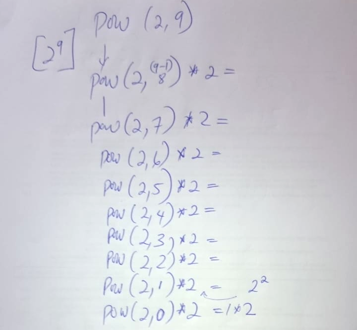

Where value of n=9, it has made a total of 10 calls, n+ 1 calls.

Number of activation records on stack is dependent on no of calls.

So how many multiplication calls are made? 9 times

Space/Memory

$O(n)$

Time Taken

$O(n)$

Is it possible to compute the answer with less number of calls?

**We know that:**

$2^8$

**can be written as:**

$(2^2)^4$

$(2*2)^4$

So if I do one multiplication on the same value multiplication will be reduced by half

**So for (can be written as):**

$2^9 = 2*(2^2)^4$

So from the observations of the above, if the power is even I can directly half it out, and for an odd power, I take one multiplication extra, then half it out.

**Even**:

$2^8 = (2^2)^4$

**Odd**:

$2^9 = 2*(2^2)^4$

**How does does this affect the time and space complexity now?**

Lets rewrite the power function....

```python
#include <iostream>
#include <climits>
#include <math.h>
using namespace std;
```

```python
int pow(int m,int n);
```

```python
int pow(int m, int n){
    if (n ==0)
       return 1;
    return pow(m,n-1)*m;
}
```

```python
int y=2, x=9, z=0;
z =pow(y,x);
```

```python
cout<<z<<endl;
```

```
512
```

## Reduced Size and speed Power Function

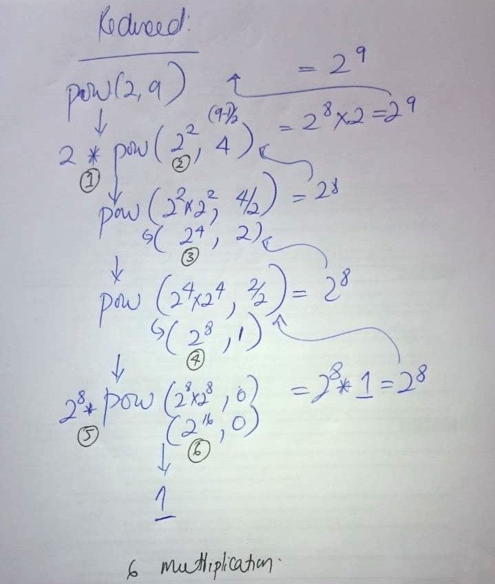

How many multiplications

We have done 6 multiplications to get answer

So this works faster.

```python
int pow2(int m,int n);
```

```python
int pow2(int m, int n){
    if (n ==0)
       return 1;
    if(n%2==0)
      return pow(m*m,n/2);
    else
      return m*pow(m*m,n/2);
}
```

```python
int a=2, b=9, c=0;
c =pow2(a,b);
```

```python
cout<<c<<endl;
```

```
512
```